# Report Exercise Chapter 5

Emma Biland

2025-05-20

## 1. Dataset description

The `airquality` dataset provides daily air quality measurements in New York City from May to September 1973. The main variable of interest is Ozone (ppb). Other variables include Solar (solar radiation in Langley), Wind (mph), Temp (Fahrenheit), and the Month and Day of the observation. Some values are missing (e.g. Ozone and Solar.R).

```r
knitr::kable(utils::head(df, 6), caption = "First six rows of the airquality dataset")
```

First six rows of the airquality dataset

| Ozone | Solar.R | Wind | Temp | Month | Day |
| --- | --- | --- | --- | --- | --- |
| 41 | 190 | 7.4 | 67 | 5 | 1 |
| 36 | 118 | 8.0 | 72 | 5 | 2 |
| 12 | 149 | 12.6 | 74 | 5 | 3 |
| 18 | 313 | 11.5 | 62 | 5 | 4 |
| NA | NA | 14.3 | 56 | 5 | 5 |
| 28 | NA | 14.9 | 66 | 5 | 6 |

## 2. Research question

> How does temperature influence ozone concentration, and are there seasonal (monthly) patterns in ozone levels?

## 3. Statistical metrics

We begin by computing a few summary statistics to better understand the key variables.

```r
df_clean <- dplyr::filter(df, !is.na(Ozone), !is.na(Temp))

summary_stats <- dplyr::summarise(
  df_clean,
  mean_ozone = round(mean(Ozone), 1),
  max_ozone = max(Ozone),
  min_ozone = min(Ozone),
  mean_temp = round(mean(Temp), 1),
  n = dplyr::n()
)

knitr::kable(summary_stats, caption = "Basic statistics on Ozone and Temperature")
```

Basic statistics on Ozone and Temperature

| mean_ozone | max_ozone | min_ozone | mean_temp | n |
| --- | --- | --- | --- | --- |
| 42.1 | 168 | 1 | 77.9 | 116 |

## 4. Figures and patterns

### a) Ozone concentration by month

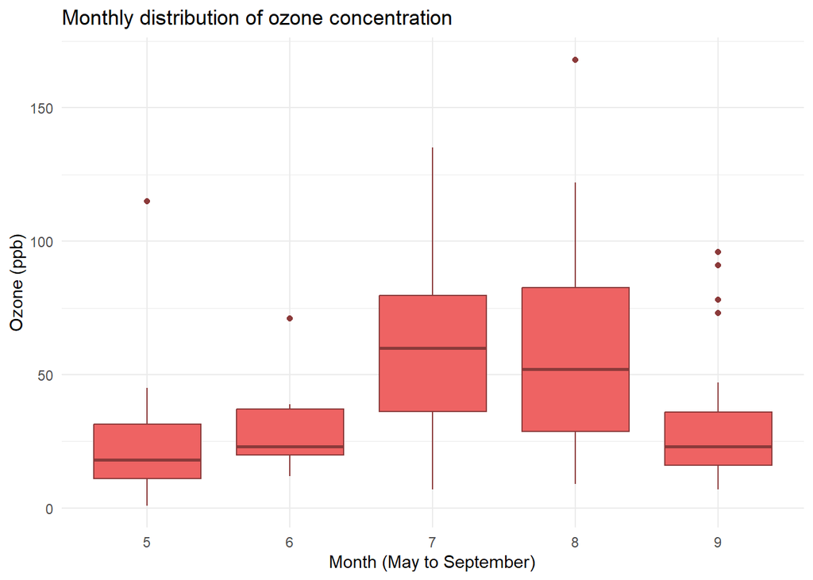

```r
ggplot2::ggplot(df, ggplot2::aes(x = factor(Month), y = Ozone)) +
  ggplot2::geom_boxplot(fill = "indianred2", color = "indianred4", na.rm = TRUE) +
  ggplot2::labs(title = "Monthly distribution of ozone concentration",
                x = "Month (May to September)", y = "Ozone (ppb)") +
  ggplot2::theme_minimal()
```

### b) Temperature vs Ozone (scatterplot)

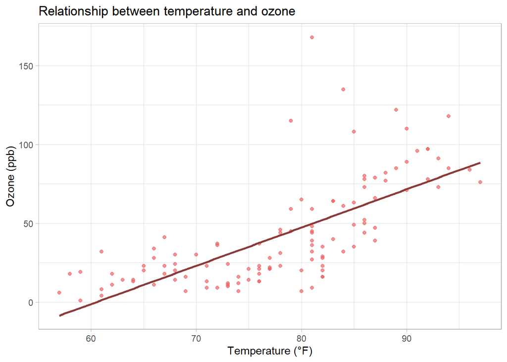

```r
ggplot2::ggplot(df_clean, ggplot2::aes(x = Temp, y = Ozone)) +
  ggplot2::geom_point(color = "indianred2", alpha = 0.7) +
  ggplot2::geom_smooth(method = "lm", se = FALSE, color = "indianred4") +
  ggplot2::labs(title = "Relationship between temperature and ozone",
                x = "Temperature (°F)", y = "Ozone (ppb)") +
  ggplot2::theme_light()
```

### c) Temporal trend in Ozone (by date)

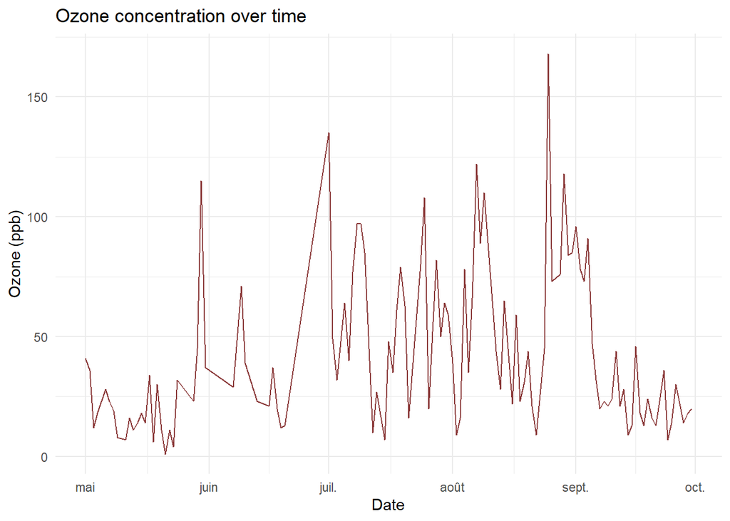

```r
df_date <- df %>%
  dplyr::filter(!is.na(Ozone)) %>%
  dplyr::mutate(date = base::as.Date(paste(1973, Month, Day, sep = "-")))

ggplot2::ggplot(df_date, ggplot2::aes(x = date, y = Ozone)) +
  ggplot2::geom_line(color = "indianred4") +
  ggplot2::labs(title = "Ozone concentration over time",
                x = "Date", y = "Ozone (ppb)") +
  ggplot2::theme_minimal()
```

## 5. Interpretation and conclusion

We observed that ozone concentration varies strongly between months, with the highest levels in July and August. A clear positive correlation is visible between temperature and ozone, suggesting that warmer days tend to have higher ozone levels — a pattern consistent with known photochemical processes.

Over time, ozone values show a noisy but slightly increasing trend toward midsummer. These results support the idea that temperature is a strong predictor of ozone, and that seasonality plays a significant role in air quality patterns.

Further exploration could include multivariate models controlling for solar radiation and wind speed to better isolate temperature effects.